# project 1

Airbnb, Inc is an American vacation rental online marketplace company based in San Francisco. Instead of holding any of the real estate listings, the company operates as a broker, receiving commissions from each booking. Airbnb offers accommodations for temporary residence, typically for homestays or tourism experiences. Since 2008, guests and hosts have utilized Airbnb to explore more travelling possibilities and present a more personalized way of experiencing the world. This dataset is downloaded from Kaggle.com, which holds free public data published by Inside Airbnb. It contains approximately 50 thousand Airbnb listings in NYC as of August 2019. The purpose of this project is to construct a model which can effectively predict the price of NYC Airbnb rentals based on factors such as neighbourhood group and room types.

It is defined that "price" is the Y variable and the rest are the X variables. I started by cleaning the data and removed unnecessary X variables from the dataset for simplification in the further analysis. I have analyzed each variable and determine the boundary that allows us to eliminate extreme values that may cause an "outlier effect" on the regression analysis later on. I have also created dummy variables by combining different groups with similar characteristics within a particular X variable.

```python
import pandas as pd
import qeds
%matplotlib inline
import qeds
qeds.themes.mpl_style();

from IPython.display import display
```

Loading the data

```python
df1 = pd.read_csv("/Users/apple/Downloads/archive/AB_NYC_2019.csv")
```

```python
df1
```

|  | id | name | host_id | host_name | neighbourhood_group | neighbourhood | latitude | longitude | room_type | price | minimum_nights | number_of_reviews | last_review | reviews_per_month | calculated_host_listings_count | availability_365 |
| --- | --- | --- | --- | --- | --- | --- | --- | --- | --- | --- | --- | --- | --- | --- | --- | --- |
| 0 | 2539 | Clean & quiet apt home by the park | 2787 | John | Brooklyn | Kensington | 40.64749 | -73.97237 | Private room | 149 | 1 | 9 | 2018-10-19 | 0.21 | 6 | 365 |
| 1 | 2595 | Skylit Midtown Castle | 2845 | Jennifer | Manhattan | Midtown | 40.75362 | -73.98377 | Entire home/apt | 225 | 1 | 45 | 2019-05-21 | 0.38 | 2 | 355 |
| 2 | 3647 | THE VILLAGE OF HARLEM....NEW YORK ! | 4632 | Elisabeth | Manhattan | Harlem | 40.80902 | -73.94190 | Private room | 150 | 3 | 0 | NaN | NaN | 1 | 365 |
| 3 | 3831 | Cozy Entire Floor of Brownstone | 4869 | LisaRoxanne | Brooklyn | Clinton Hill | 40.68514 | -73.95976 | Entire home/apt | 89 | 1 | 270 | 2019-07-05 | 4.64 | 1 | 194 |
| 4 | 5022 | Entire Apt: Spacious Studio/Loft by central park | 7192 | Laura | Manhattan | East Harlem | 40.79851 | -73.94399 | Entire home/apt | 80 | 10 | 9 | 2018-11-19 | 0.10 | 1 | 0 |
| ... | ... | ... | ... | ... | ... | ... | ... | ... | ... | ... | ... | ... | ... | ... | ... | ... |
| 48890 | 36484665 | Charming one bedroom - newly renovated rowhouse | 8232441 | Sabrina | Brooklyn | Bedford-Stuyvesant | 40.67853 | -73.94995 | Private room | 70 | 2 | 0 | NaN | NaN | 2 | 9 |
| 48891 | 36485057 | Affordable room in Bushwick/East Williamsburg | 6570630 | Marisol | Brooklyn | Bushwick | 40.70184 | -73.93317 | Private room | 40 | 4 | 0 | NaN | NaN | 2 | 36 |
| 48892 | 36485431 | Sunny Studio at Historical Neighborhood | 23492952 | Ilgar & Aysel | Manhattan | Harlem | 40.81475 | -73.94867 | Entire home/apt | 115 | 10 | 0 | NaN | NaN | 1 | 27 |
| 48893 | 36485609 | 43rd St. Time Square-cozy single bed | 30985759 | Taz | Manhattan | Hell's Kitchen | 40.75751 | -73.99112 | Shared room | 55 | 1 | 0 | NaN | NaN | 6 | 2 |
| 48894 | 36487245 | Trendy duplex in the very heart of Hell's Kitchen | 68119814 | Christophe | Manhattan | Hell's Kitchen | 40.76404 | -73.98933 | Private room | 90 | 7 | 0 | NaN | NaN | 1 | 23 |

48895 rows × 16 columns

The total number of observations is 48895, with 16 variables.

Let's first determine the types of every variable

```python
df1.dtypes
```

```
id                                  int64
name                               object
host_id                             int64
host_name                          object
neighbourhood_group                object
neighbourhood                      object
latitude                          float64
longitude                         float64
room_type                          object
price                               int64
minimum_nights                      int64
number_of_reviews                   int64
last_review                        object
reviews_per_month                 float64
calculated_host_listings_count      int64
availability_365                    int64
dtype: object
```

Check for the null values for all columns

```python
df1.isnull().sum()
```

```
id                                    0
name                                 16
host_id                               0
host_name                            21
neighbourhood_group                   0
neighbourhood                         0
latitude                              0
longitude                             0
room_type                             0
price                                 0
minimum_nights                        0
number_of_reviews                     0
last_review                       10052
reviews_per_month                 10052
calculated_host_listings_count        0
availability_365                      0
dtype: int64
```

Since ids and hosts' names may not be very helpful for the analysis, I will drop them

```python
df1.drop(["id","host_id","host_name"], axis=1, inplace=True)
```

Check null values and replace them by 0 for int/float variables, or "" for string variables

```python
df1.fillna({"name": "", "reviews_per_month":0, "last_review" : ""}, inplace=True)
```

```python
df1.isnull().sum()
```

```
name                              0
neighbourhood_group               0
neighbourhood                     0
latitude                          0
longitude                         0
room_type                         0
price                             0
minimum_nights                    0
number_of_reviews                 0
last_review                       0
reviews_per_month                 0
calculated_host_listings_count    0
availability_365                  0
dtype: int64
```

Move the Y-variable "price" to the first column for better presentation

```python
columns_titles = ["price", "name", "host_name", "neighbourhood_group", "neighbourhood",
                  "latitude", "longitude", "room_type", "minimum_nights",
                  "number_of_reviews", "last_review", "reviews_per_month",
                  "calculated_host_listings_count","availability_365"]
df2 = df1.reindex(columns=columns_titles)
df2
```

|  | price | name | host_name | neighbourhood_group | neighbourhood | latitude | longitude | room_type | minimum_nights | number_of_reviews | last_review | reviews_per_month | calculated_host_listings_count | availability_365 |
| --- | --- | --- | --- | --- | --- | --- | --- | --- | --- | --- | --- | --- | --- | --- |
| 0 | 149 | Clean & quiet apt home by the park | NaN | Brooklyn | Kensington | 40.64749 | -73.97237 | Private room | 1 | 9 | 2018-10-19 | 0.21 | 6 | 365 |
| 1 | 225 | Skylit Midtown Castle | NaN | Manhattan | Midtown | 40.75362 | -73.98377 | Entire home/apt | 1 | 45 | 2019-05-21 | 0.38 | 2 | 355 |
| 2 | 150 | THE VILLAGE OF HARLEM....NEW YORK ! | NaN | Manhattan | Harlem | 40.80902 | -73.94190 | Private room | 3 | 0 |  | 0.00 | 1 | 365 |
| 3 | 89 | Cozy Entire Floor of Brownstone | NaN | Brooklyn | Clinton Hill | 40.68514 | -73.95976 | Entire home/apt | 1 | 270 | 2019-07-05 | 4.64 | 1 | 194 |
| 4 | 80 | Entire Apt: Spacious Studio/Loft by central park | NaN | Manhattan | East Harlem | 40.79851 | -73.94399 | Entire home/apt | 10 | 9 | 2018-11-19 | 0.10 | 1 | 0 |
| ... | ... | ... | ... | ... | ... | ... | ... | ... | ... | ... | ... | ... | ... | ... |
| 48890 | 70 | Charming one bedroom - newly renovated rowhouse | NaN | Brooklyn | Bedford-Stuyvesant | 40.67853 | -73.94995 | Private room | 2 | 0 |  | 0.00 | 2 | 9 |
| 48891 | 40 | Affordable room in Bushwick/East Williamsburg | NaN | Brooklyn | Bushwick | 40.70184 | -73.93317 | Private room | 4 | 0 |  | 0.00 | 2 | 36 |
| 48892 | 115 | Sunny Studio at Historical Neighborhood | NaN | Manhattan | Harlem | 40.81475 | -73.94867 | Entire home/apt | 10 | 0 |  | 0.00 | 1 | 27 |
| 48893 | 55 | 43rd St. Time Square-cozy single bed | NaN | Manhattan | Hell's Kitchen | 40.75751 | -73.99112 | Shared room | 1 | 0 |  | 0.00 | 6 | 2 |
| 48894 | 90 | Trendy duplex in the very heart of Hell's Kitchen | NaN | Manhattan | Hell's Kitchen | 40.76404 | -73.98933 | Private room | 7 | 0 |  | 0.00 | 1 | 23 |

48895 rows × 14 columns

To start analyzing the data, we can first look at the summary statistics of each variable

```python
df2.describe()
```

|  | price | host_name | latitude | longitude | minimum_nights | number_of_reviews | reviews_per_month | calculated_host_listings_count | availability_365 |
| --- | --- | --- | --- | --- | --- | --- | --- | --- | --- |
| count | 48895.000000 | 0.0 | 48895.000000 | 48895.000000 | 48895.000000 | 48895.000000 | 48895.000000 | 48895.000000 | 48895.000000 |
| mean | 152.720687 | NaN | 40.728949 | -73.952170 | 7.029962 | 23.274466 | 1.090910 | 7.143982 | 112.781327 |
| std | 240.154170 | NaN | 0.054530 | 0.046157 | 20.510550 | 44.550582 | 1.597283 | 32.952519 | 131.622289 |
| min | 0.000000 | NaN | 40.499790 | -74.244420 | 1.000000 | 0.000000 | 0.000000 | 1.000000 | 0.000000 |
| 25% | 69.000000 | NaN | 40.690100 | -73.983070 | 1.000000 | 1.000000 | 0.040000 | 1.000000 | 0.000000 |
| 50% | 106.000000 | NaN | 40.723070 | -73.955680 | 3.000000 | 5.000000 | 0.370000 | 1.000000 | 45.000000 |
| 75% | 175.000000 | NaN | 40.763115 | -73.936275 | 5.000000 | 24.000000 | 1.580000 | 2.000000 | 227.000000 |
| max | 10000.000000 | NaN | 40.913060 | -73.712990 | 1250.000000 | 629.000000 | 58.500000 | 327.000000 | 365.000000 |

```python
df2["price"].describe()
```

```
count    48895.000000
mean       152.720687
std        240.154170
min          0.000000
25%         69.000000
50%        106.000000
75%        175.000000
max      10000.000000
Name: price, dtype: float64
```

The range is 10000 which is quite big. The 75% percentile is only 175. The distribution is extremely positively skewed and it is better to draft a histogram for further analysis.

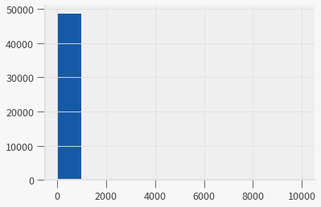

```python
hist_price = df2["price"].hist()
```

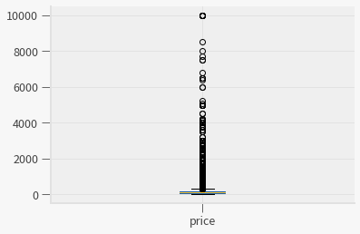

```python
df2["price"].plot.box()
```

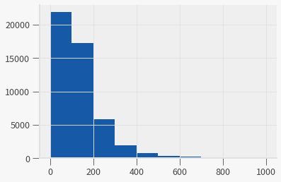

```python
hist_price1=df2["price"][df2["price"]<1000].hist()
```

```python
df2["price"][df2["price"] < 1000]
```

```
0        149
1        225
2        150
3         89
4         80
        ...
48890     70
48891     40
48892    115
48893     55
48894     90
Name: price, Length: 48597, dtype: int64
```

The total nunmber of listing less than 1000 is 48597. Simply we can calculate the percentage of listings less than 1000: 48597/48895 = 0.9939 = 99.39% There are more than 99% listings less than 1000.

```python
price_less1000 = (df2[df2["price"] < 1000])
```

Save a new dataframe containing listings only below 1000, which may be helpful in the regression analysis later on. However, I will use the original dataset to continue examining other X variables first.

Next, let's look at neighbourhood groups.

```python
df2['neighbourhood_group'].value_counts()
```

```
Manhattan        21661
Brooklyn         20104
Queens            5666
Bronx             1091
Staten Island      373
Name: neighbourhood_group, dtype: int64
```

Create a groupby to investigate the descriptive statistics of "price" in different groups

```python
group1 = df2.groupby("neighbourhood_group")
```

```python
group1["price"].describe()
```

| neighbourhood_group | count | mean | std | min | 25% | 50% | 75% | max |
| --- | --- | --- | --- | --- | --- | --- | --- | --- |
| Bronx | 1091.0 | 87.496792 | 106.709349 | 0.0 | 45.0 | 65.0 | 99.0 | 2500.0 |
| Brooklyn | 20104.0 | 124.383207 | 186.873538 | 0.0 | 60.0 | 90.0 | 150.0 | 10000.0 |
| Manhattan | 21661.0 | 196.875814 | 291.383183 | 0.0 | 95.0 | 150.0 | 220.0 | 10000.0 |
| Queens | 5666.0 | 99.517649 | 167.102155 | 10.0 | 50.0 | 75.0 | 110.0 | 10000.0 |
| Staten Island | 373.0 | 114.812332 | 277.620403 | 13.0 | 50.0 | 75.0 | 110.0 | 5000.0 |

Brooklyn and Manhattan has accounted for approximately 85% of the listings. On average, the cost of living in Manhattan is the highest, while Bronx has the cheapest rent. Recalling that there are many "outliers" in "price", it is referable that the standard deviations of price in the five neighbourhood groups are high.

We can create a dummy variable which equals 1 if the listing is in Manhattan or Brooklyn, and 0 if it is in Staten Island, Queens or Bronx. The reason why I grouped Manhattan and Brooklyn is that they contain the most of the listings with a higher average price.

```python
df2["n_dummy"] = df2.neighbourhood_group.map({"Manhattan":1, "Brooklyn":1,
                                              "Staten Island":0, "Queens":0, "Bronx":0})
```

```python
df2["neighbourhood"].value_counts()
```

```
Williamsburg          3920
Bedford-Stuyvesant    3714
Harlem                2658
Bushwick              2465
Upper West Side       1971
                      ...
Fort Wadsworth           1
Richmondtown             1
Rossville                1
New Dorp                 1
Willowbrook              1
Name: neighbourhood, Length: 221, dtype: int64
```

There are 221 unique neighbourhoods in NYC for this dataset. Most listings are in Williamsburg

```python
df2['room_type'].value_counts()
```

```
Entire home/apt    25409
Private room       22326
Shared room         1160
Name: room_type, dtype: int64
```

```python
group2 = df2.groupby("room_type")
group2["price"].describe()
```

| room_type | count | mean | std | min | 25% | 50% | 75% | max |
| --- | --- | --- | --- | --- | --- | --- | --- | --- |
| Entire home/apt | 25409.0 | 211.794246 | 284.041611 | 0.0 | 120.0 | 160.0 | 229.0 | 10000.0 |
| Private room | 22326.0 | 89.780973 | 160.205262 | 0.0 | 50.0 | 70.0 | 95.0 | 10000.0 |
| Shared room | 1160.0 | 70.127586 | 101.725252 | 0.0 | 33.0 | 45.0 | 75.0 | 1800.0 |

Listings that is an entire home/apartment costs the most, with an average price of 212. Since the total number of shared room listings is relatively small and its average price does not differ to private room listings as much as enire home/apt, we can group private room and shared room in one when creating a dummy variable.

```python
df2["room_dummy"] = df2.room_type.map({"Entire home/apt":1,
                                       "Private room":0, "Shared room":0})
```

The dummy variable equals 1 when the listing is an entire home/apartment and 0 otherwise.

Moving on, let's look at the map coordinates.

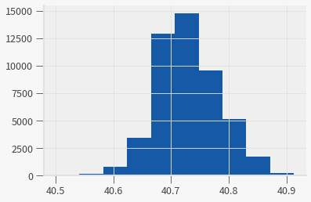

```python
hist_latitude = df2["latitude"].hist()
```

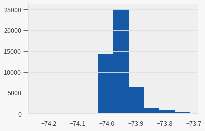

```python
hist_longitude = df2["longitude"].hist()
```

The range of latitude and longitude is pretty small. It may not be helpful by just investigating the effect of only one single variable as the difference among the variables are pretty small.

We can plot a scatterplot

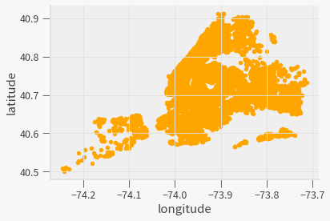

```python
ax1 = df2.plot.scatter(x="longitude",y="latitude", c="orange")
```

```python
new = ["longitude", "latitude", "price"]
coordinates = df2.reindex(columns = new)
coordinates.corr()
```

|  | longitude | latitude | price |
| --- | --- | --- | --- |
| longitude | 1.000000 | 0.084788 | -0.150019 |
| latitude | 0.084788 | 1.000000 | 0.033939 |
| price | -0.150019 | 0.033939 | 1.000000 |

As shown above, the correlation between latitude and longitude is weak. If we interpret the scatterplot as a map, the distibution of Airbnb listings in NYC is pretty random for longitude > -74.0 and latitude > 40.6, which contains most of the observations in our data.

The correlation between price and latitude, price and longitude is also not significant. Thus, the map coordinates of a Airbnb listing may not have significant effect on its price. We can drop the two columns from the dataset.

```python
df2.drop(["latitude", "longitude"], axis=1, inplace=True)
```

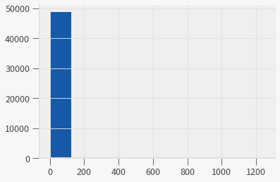

```python
hist_minimum_nights = df2["minimum_nights"].hist()
```

It shows that a majority of listings have less than 200 nights. Recalling that the mean of minimum_nights is around 7 and standard deviation is 20.5, the outliers would be outside three deviations from the mean, which is 68.5 in this case

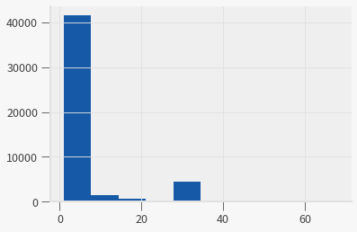

```python
hist_minimum_nights = df2["minimum_nights"][df2["minimum_nights"] < 70].hist()
```

```python
df2["minimum_nights"][df2["minimum_nights"] < 70]
```

```
0         1
1         1
2         3
3         1
4        10
         ..
48890     2
48891     4
48892    10
48893     1
48894     7
Name: minimum_nights, Length: 48568, dtype: int64
```

There are around 99% of listings having minimum nights less than 70. We can set 70 as the boundary to opt out extreme values if necessary in the later regression analysis.

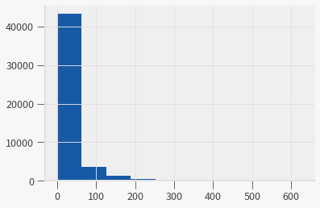

```python
hist_number_of_reviews = df2["number_of_reviews"].hist()
```

It shows that a majority of listings have less than 200 reviews. Recalling that the mean of number_of_reviews is around 23.3 and standard deviation is 44.6, the outliers would be outside three deviations from the mean, which is approximately 157 in this case

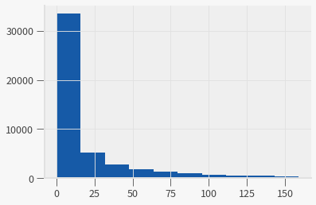

```python
hist_number_of_reviews = df2["number_of_reviews"][df2["number_of_reviews"] < 160].hist()
```

```python
df2["number_of_reviews"][df2["number_of_reviews"] < 160]
```

```
0         9
1        45
2         0
4         9
5        74
         ..
48890     0
48891     0
48892     0
48893     0
48894     0
Name: number_of_reviews, Length: 47720, dtype: int64
```

There are around 97.6% listings receiving less than 160 number of reviews. We can also set 160 as the boundary of removing outliers for this variable.

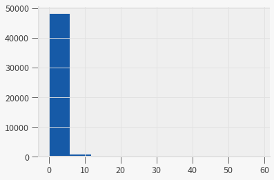

```python
hist_reviews_per_month = df2["reviews_per_month"].hist()
```

It shows that a majority of listings have less than 10 reviews per month. Recalling that the mean of reviews_per_month is around 1.09 and standard deviation is 1.6, the outliers would be outside three deviations from the mean, which is approximately 5.89 in this case

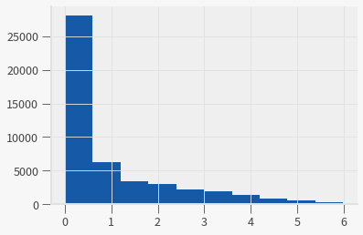

```python
hist_reviews_per_month = df2["reviews_per_month"][df2["reviews_per_month"] < 6].hist()
```

```python
df2["reviews_per_month"][df2["reviews_per_month"] < 6]
```

```
0        0.21
1        0.38
2        0.00
3        4.64
4        0.10
         ...
48890    0.00
48891    0.00
48892    0.00
48893    0.00
48894    0.00
Name: reviews_per_month, Length: 48104, dtype: float64
```

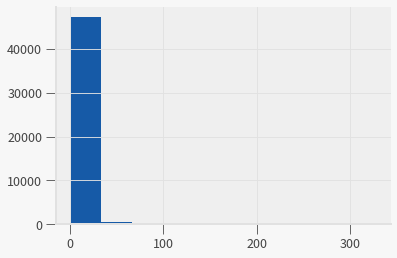

```python
hist_calculated_host_listings_count = df2["calculated_host_listings_count"].hist()
```

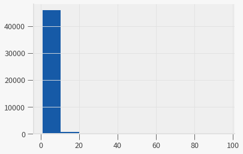

```python
hist_calculated_host_listings_count = df2["calculated_host_listings_count"][df2["calculated_host_listings_count"] < 100].hist()
```

```python
df2["calculated_host_listings_count"][df2["calculated_host_listings_count"] < 10]
```

```
0        6
1        2
2        1
3        1
4        1
        ..
48890    2
48891    2
48892    1
48893    6
48894    1
Name: calculated_host_listings_count, Length: 45718, dtype: int64
```

Among all observations, the hosts of 94% listings have less than 10 total listings.

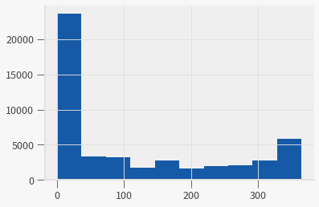

```python
hist_availability_365 = df2["availability_365"].hist()
```

Let's examine the overall correlation

```python
df2.corr()
```

|  | price | host_name | minimum_nights | number_of_reviews | reviews_per_month | calculated_host_listings_count | availability_365 | n_dummy | room_dummy |
| --- | --- | --- | --- | --- | --- | --- | --- | --- | --- |
| price | 1.000000 | NaN | 0.042799 | -0.047954 | -0.050564 | 0.057472 | 0.081829 | 0.093323 | 0.255857 |
| host_name | NaN | NaN | NaN | NaN | NaN | NaN | NaN | NaN | NaN |
| minimum_nights | 0.042799 | NaN | 1.000000 | -0.080116 | -0.124905 | 0.127960 | 0.144303 | 0.039520 | 0.074900 |
| number_of_reviews | -0.047954 | NaN | -0.080116 | 1.000000 | 0.589407 | -0.072376 | 0.172028 | -0.040213 | -0.010087 |
| reviews_per_month | -0.050564 | NaN | -0.124905 | 0.589407 | 1.000000 | -0.047312 | 0.163732 | -0.119681 | -0.029565 |
| calculated_host_listings_count | 0.057472 | NaN | 0.127960 | -0.072376 | -0.047312 | 1.000000 | 0.225701 | 0.043313 | 0.112193 |
| availability_365 | 0.081829 | NaN | 0.144303 | 0.172028 | 0.163732 | 0.225701 | 1.000000 | -0.118723 | -0.006804 |
| n_dummy | 0.093323 | NaN | 0.039520 | -0.040213 | -0.119681 | 0.043313 | -0.118723 | 1.000000 | 0.122276 |
| room_dummy | 0.255857 | NaN | 0.074900 | -0.010087 | -0.029565 | 0.112193 | -0.006804 | 0.122276 | 1.000000 |

As shown in the first column, the correlation coefficients are not very high, implying that the relationship between the Y variable "price" and other X variables is not strong.

```python
df2.cov()
```

|  | price | host_name | minimum_nights | number_of_reviews | reviews_per_month | calculated_host_listings_count | availability_365 | n_dummy | room_dummy |
| --- | --- | --- | --- | --- | --- | --- | --- | --- | --- |
| price | 57674.025247 | NaN | 210.816423 | -513.062658 | -19.396088 | 454.812827 | 2586.579899 | 7.909917 | 30.699064 |
| host_name | NaN | NaN | NaN | NaN | NaN | NaN | NaN | NaN | NaN |
| minimum_nights | 210.816423 | NaN | 420.682642 | -73.206612 | -4.092030 | 86.484621 | 389.567112 | 0.286081 | 0.767532 |
| number_of_reviews | -513.062658 | NaN | -73.206612 | 1984.754380 | 41.942151 | -106.251958 | 1008.743866 | -0.632287 | -0.224524 |
| reviews_per_month | -19.396088 | NaN | -4.092030 | 41.942151 | 2.551312 | -2.490246 | 34.422621 | -0.067468 | -0.023594 |
| calculated_host_listings_count | 454.812827 | NaN | 86.484621 | -106.251958 | -2.490246 | 1085.868499 | 978.931391 | 0.503734 | 1.847109 |
| availability_365 | 2586.579899 | NaN | 389.567112 | 1008.743866 | 34.422621 | 978.931391 | 17324.426923 | -5.515117 | -0.447453 |
| n_dummy | 7.909917 | NaN | 0.286081 | -0.632287 | -0.067468 | 0.503734 | -5.515117 | 0.124561 | 0.021561 |
| room_dummy | 30.699064 | NaN | 0.767532 | -0.224524 | -0.023594 | 1.847109 | -0.447453 | 0.021561 | 0.249618 |